# Identify Genome 1/2

Will Hannon

1/26/2022

The goal of this notebook is to identify all of the mutations in genome-1 and genome-2, the two major background strains present in the brain.

## Processing the variant data

I used three different variant callers to identify mutations in the measles virus genome. In the abscense of replicates, this is a way to control of issues in the variant calling pipelines that could lead to errors. In addition to these different variant calling approaches, I’ve set a cutoff of 200X coverage and a minimum allele frequency of 2% of reads.

To identify a set of mutations to go forward with, I’ll combine the mutations from each variant caller and control of SNPs that might be lower frequency in a single sample due to low coverage.

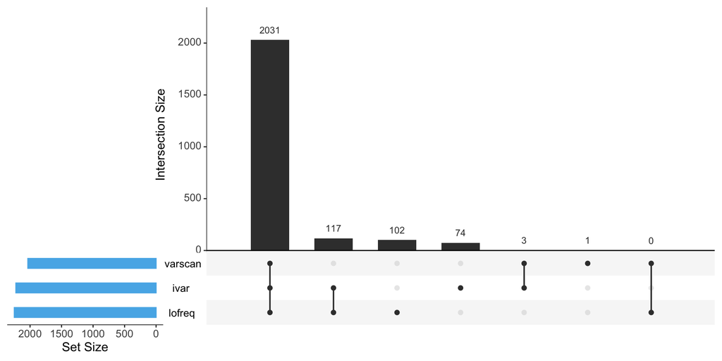

To get the final set of variants, I’m going to ignore `ivar` which I’ve had mixed experiences with in the past. Then, I’ll resolve some of the mutations that show up in one variant caller, but are missing from the other. I’ll find the mutations that are called by `varscan` and `lofreq` in at least a single tissue. Then, I go through each tissue and resolve the mutations are called by both, but missing from one in that specific tissue. I’ll write these out to a file for other analyses (`final_variants.csv`).

```
## [1] "There are 497 unique quality variants."
```

```
## [1] "There are 83 instances in which one variant caller picks up on a mutation that's missing from the other."
```

[output not shown]

## What is the distribution of these mutations?

It’s important to know the distribution of these mutations in each sample because it will help select regions of the genome to haplotype. The highest density of mutations in over the Matrix protein, but it’s further import to color these by the major genotypes, because these will tell us how easily we can determine what the full haplotypes are.

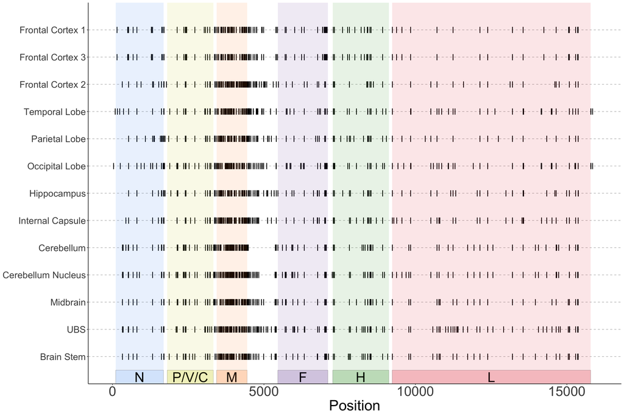

## What are the two major backgrounds?

We know from experiments and observation that there are two sets of mutations that are present in every tissue sample. These mutations are on the background of every other sample in the genome. Because they are in every sample and anti-correlated, we should be able to identify these mutaitons by clustering them based on their co-correlation.

```
## [1] "There are 66 mutations in every tissue sample"
```

I’ll make a correlation matrix between all of the SNPs that are found in every tissue and aren’t fixed in every tissue (four mutations are fixed in every tissue but not included in the SSPE reference).

```
## [1] "There are 4 fixed mutations in every tissue sample that aren't in the reference."
```

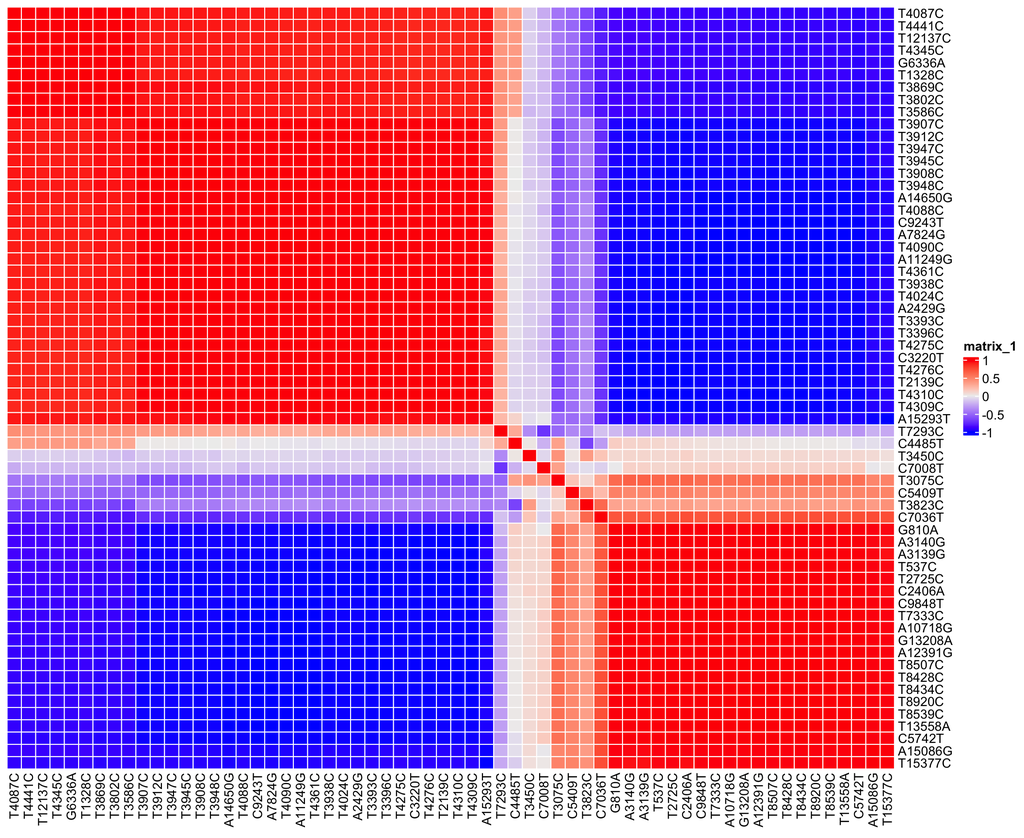

Most are strongly correlated, but some aren’t so correlated with one another. Here is a histogram showing that. I’ll filter out those SNPs that aren’t so well correlated with one another while identifying the mutations on Genome-1 and Genome-2.

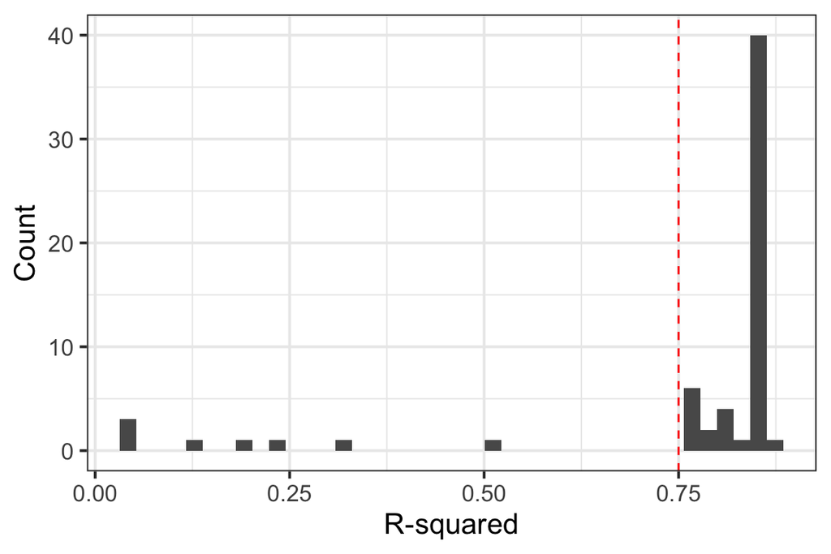

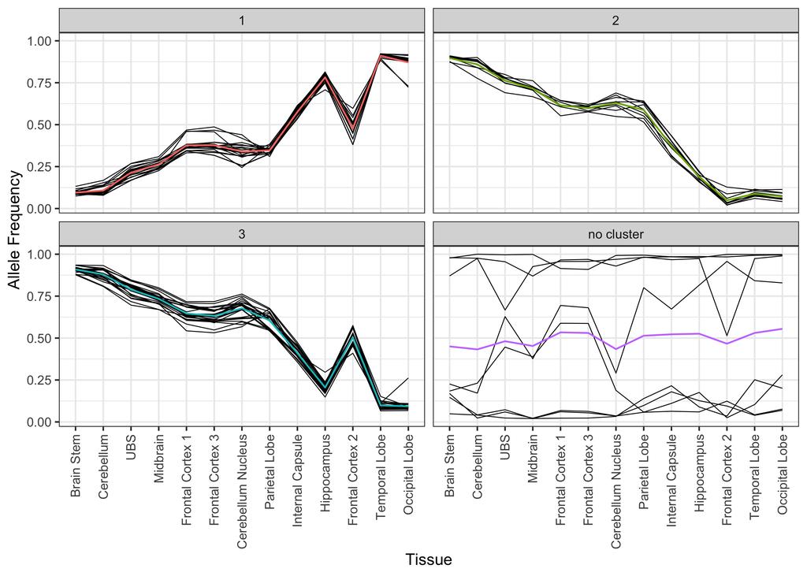

This is the distribution of genome-1 and genome-2 in the brain.

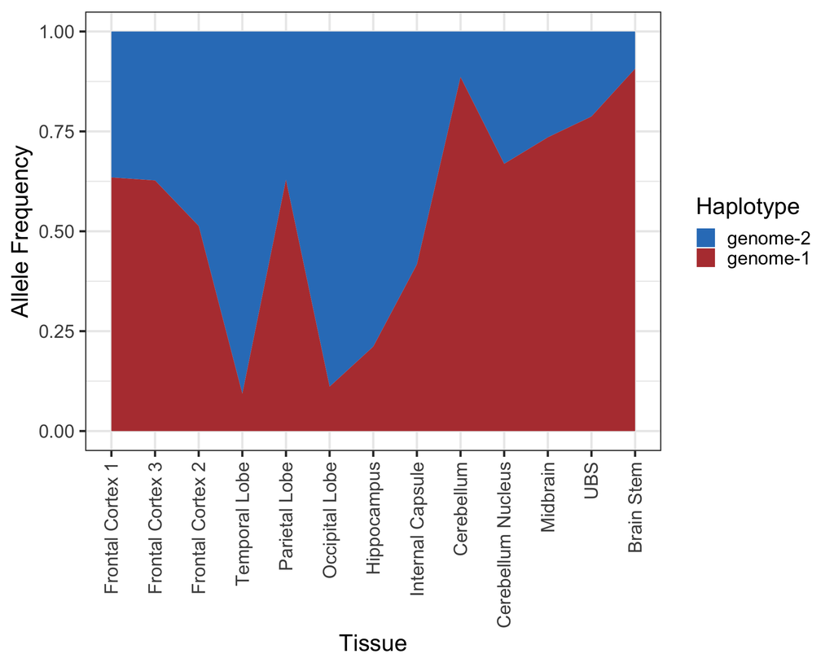

Now I can color the mutations by their presence in Genome-1 and Genome-2 to see their distribution in the genome

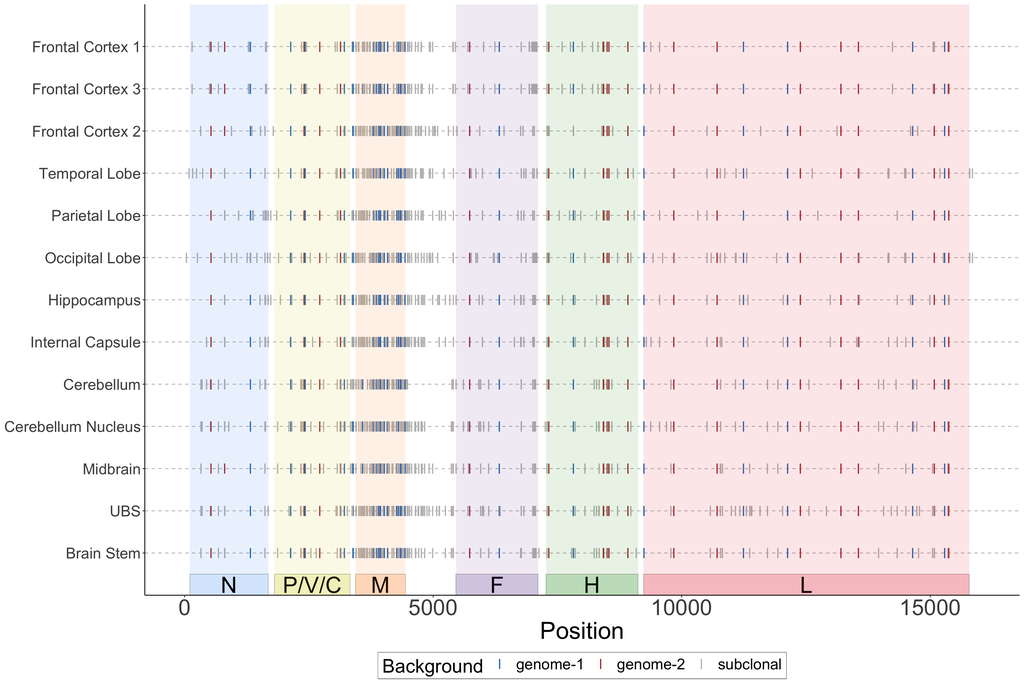

## END